```python
import numpy as np
import pandas as pd
import datetime

import matplotlib.pyplot as plt
import seaborn as sns
sns.set()

from sklearn.model_selection import train_test_split

import os
```

# LOAD THE EXPORTED DATASETS

```python
#input-train data
filename1 = r'C:\Users\13134\Documents\GitHub\Capstone-2\Data Pre-Processing\data\loan_data_inputs_train.csv'
loan_data_inputs_train = pd.read_csv(filename1, index_col = 0)

#input-test data
filename2 = r'C:\Users\13134\Documents\GitHub\Capstone-2\Data Pre-Processing\data\loan_data_inputs_test.csv'
loan_data_inputs_test = pd.read_csv(filename2, index_col = 0)

#targets-train data
filename3 = r'C:\Users\13134\Documents\GitHub\Capstone-2\Data Pre-Processing\data\loan_data_targets_train.csv'
loan_data_targets_train = pd.read_csv(filename3, index_col = 0)

#targets-test data
filename4 = r'C:\Users\13134\Documents\GitHub\Capstone-2\Data Pre-Processing\data\loan_data_targets_test.csv'
loan_data_targets_test = pd.read_csv(filename4, index_col = 0)
```

**Exploring the Data**

```python
#inputs-train data
#loan_data_inputs_train.head()
```

```python
#targets-train data
#loan_data_targets_train.head()
```

```python
#inputs-test data
#loan_data_inputs_test.head()
```

```python
#targets-test data
#loan_data_targets_test.head()
```

```python
loan_data_inputs_train.shape
```

```
(1808534, 394)
```

```python
loan_data_targets_train.shape
```

```
(1808534, 1)
```

```python
loan_data_inputs_test.shape
```

```
(452134, 394)
```

```python
loan_data_targets_test.shape
```

```
(452134, 1)
```

**Selecting the Features**

```python
# Here we select a limited set of input variables in a new dataframe.
inputs_train_with_ref_cat = loan_data_inputs_train[['grade:A',
'grade:B',
'grade:C',
'grade:D',
'grade:E',
'grade:F',
'grade:G',
'home_ownership:RENT_OTHER_NONE_ANY',
'home_ownership:OWN',
'home_ownership:MORTGAGE',
'addr_state:ND_NE_IA_NV_FL_HI_AL',
'addr_state:NM_VA',
'addr_state:NY',
'addr_state:OK_TN_MO_LA_MD_NC',
'addr_state:CA',
'addr_state:UT_KY_AZ_NJ',
'addr_state:AR_MI_PA_OH_MN',
'addr_state:RI_MA_DE_SD_IN',
'addr_state:GA_WA_OR',
'addr_state:WI_MT',
'addr_state:TX',
'addr_state:IL_CT',
'addr_state:KS_SC_CO_VT_AK_MS',
'addr_state:WV_NH_WY_DC_ME_ID',
'verification_status:Not Verified',
'verification_status:Source Verified',
'verification_status:Verified',
'purpose:educ__sm_b__wedd__ren_en__mov__house',
'purpose:credit_card',
'purpose:debt_consolidation',
'purpose:oth__med__vacation',
'purpose:major_purch__car__home_impr',
'initial_list_status:f',
'initial_list_status:w',
'term:36',
'term:60',
'emp_length:0',
'emp_length:1',
'emp_length:2-4',
'emp_length:5-6',
'emp_length:7-9',
'emp_length:10',
'mths_since_issue_d:<38',
'mths_since_issue_d:38-39',
'mths_since_issue_d:40-41',
'mths_since_issue_d:42-48',
'mths_since_issue_d:49-52',
'mths_since_issue_d:53-64',
'mths_since_issue_d:65-84',
'mths_since_issue_d:>84',
'int_rate:<9.548',
'int_rate:9.548-12.025',
'int_rate:12.025-15.74',
'int_rate:15.74-20.281',
'int_rate:>20.281',
'mths_since_earliest_cr_line:<140',
'mths_since_earliest_cr_line:141-164',
'mths_since_earliest_cr_line:165-247',
'mths_since_earliest_cr_line:248-270',
'mths_since_earliest_cr_line:271-352',
'mths_since_earliest_cr_line:>352',
'delinq_2yrs:0',
'delinq_2yrs:1-3',
'delinq_2yrs:>=4',
'inq_last_6mths:0',
'inq_last_6mths:1-2',
'inq_last_6mths:3-6',
'inq_last_6mths:>6',
'open_acc:0',
'open_acc:1-3',
'open_acc:4-12',
'open_acc:13-17',
'open_acc:18-22',
'open_acc:23-25',
'open_acc:26-30',
'open_acc:>=31',
'pub_rec:0-2',
'pub_rec:3-4',
'pub_rec:>=5',
'total_acc:<=27',
'total_acc:28-51',
'total_acc:>=52',
'acc_now_delinq:0',
'acc_now_delinq:>=1',
'total_rev_hi_lim:<=5K',
'total_rev_hi_lim:5K-10K',
'total_rev_hi_lim:10K-20K',
'total_rev_hi_lim:20K-30K',
'total_rev_hi_lim:30K-40K',
'total_rev_hi_lim:40K-55K',
'total_rev_hi_lim:55K-95K',
'total_rev_hi_lim:>95K',
'annual_inc:<20K',
'annual_inc:20K-30K',
'annual_inc:30K-40K',
'annual_inc:40K-50K',
'annual_inc:50K-60K',
'annual_inc:60K-70K',
'annual_inc:70K-80K',
'annual_inc:80K-90K',
'annual_inc:90K-100K',
'annual_inc:100K-120K',
'annual_inc:120K-140K',
'annual_inc:>140K',
'dti:<=1.4',
'dti:1.4-3.5',
'dti:3.5-7.7',
'dti:7.7-10.5',
'dti:10.5-16.1',
'dti:16.1-20.3',
'dti:20.3-21.7',
'dti:21.7-22.4',
'dti:22.4-35',
'dti:>35',
'mths_since_last_delinq:Missing',
'mths_since_last_delinq:0-3',
'mths_since_last_delinq:4-30',
'mths_since_last_delinq:31-56',
'mths_since_last_delinq:>=57',
'mths_since_last_record:Missing',
'mths_since_last_record:0-2',
'mths_since_last_record:3-20',
'mths_since_last_record:21-31'
]]
```

```python
# Here we store the names of the reference category dummy variables in a list.

ref_categories = ['grade:G',
'home_ownership:RENT_OTHER_NONE_ANY',
'addr_state:ND_NE_IA_NV_FL_HI_AL',
'verification_status:Verified',
'purpose:educ__sm_b__wedd__ren_en__mov__house',
'initial_list_status:f',
'term:60',
'emp_length:0',
'mths_since_issue_d:>84',
'int_rate:>20.281',
'mths_since_earliest_cr_line:<140',
'delinq_2yrs:>=4',
'inq_last_6mths:>6',
'open_acc:0',
'pub_rec:0-2',
'total_acc:<=27',
'acc_now_delinq:0',
'total_rev_hi_lim:<=5K',
'annual_inc:<20K',
'dti:>35',
'mths_since_last_delinq:0-3',
'mths_since_last_record:0-2']
```

```python
# From the dataframe with input variables, we drop the variables with variable names in the list with reference categories.

inputs_train = inputs_train_with_ref_cat.drop(ref_categories, axis = 1)
#inputs_train.head()
```

# PROPABILITY OF DEFAULT (PD) MODEL ESTIMATION

**We will be using Logistic Regression for our PD Model**

```python
from sklearn.linear_model import LogisticRegression
from sklearn import metrics

from sklearn import linear_model
import scipy.stats as stat
```

```python
# P values for sklearn logistic regression.

# Class to display p-values for logistic regression in sklearn.

class LogisticRegression_with_p_values:

    def __init__(self,*args,**kwargs):#,**kwargs):
        self.model = linear_model.LogisticRegression(*args,**kwargs)#,**args)

    def fit(self,X,y):
        self.model.fit(X,y)

        #### Get p-values for the fitted model ####
        denom = (2.0 * (1.0 + np.cosh(self.model.decision_function(X))))
        denom = np.tile(denom,(X.shape[1],1)).T
        F_ij = np.dot((X / denom).T,X) ## Fisher Information Matrix
        Cramer_Rao = np.linalg.inv(F_ij) ## Inverse Information Matrix
        sigma_estimates = np.sqrt(np.diagonal(Cramer_Rao))
        z_scores = self.model.coef_[0] / sigma_estimates # z-score for eaach model coefficient
        p_values = [stat.norm.sf(abs(x)) * 2 for x in z_scores] ### two tailed test for p-values

        self.coef_ = self.model.coef_
        self.intercept_ = self.model.intercept_
        self.p_values = p_values
```

```python
# We create an instance of an object from the newly created 'LogisticRegression_with_p_values()' class
reg = LogisticRegression_with_p_values()
```

```python
# Sets the pandas dataframe options to display all columns/ rows.
pd.options.display.max_rows = None
```

```python
# Estimates the coefficients of the object from the 'LogisticRegression' class
# with inputs (independent variables) contained in the first dataframe
# and targets (dependent variables) contained in the second dataframe.
reg.fit(inputs_train, loan_data_targets_train)
```

```python
# Displays the intercept contain in the estimated ("fitted") object from the 'LogisticRegression' class.
reg.intercept_
```

```
array([0.21538913])
```

```python
# Displays the coefficients contained in the estimated ("fitted") object from the 'LogisticRegression' class.
reg.coef_
```

```
array([[ 2.19431837,  1.66341147,  1.29339115,  0.86337279,  0.46869783,
         0.15218737,  0.11155706,  0.24280528,  0.04973625,  0.00312667,
         0.01066878,  0.0492158 ,  0.06505773,  0.09482844,  0.08861995,
         0.3021583 ,  0.21183267,  0.0706949 ,  0.26441626,  0.28688042,
         0.42423384,  0.2501805 ,  0.05904257,  0.1344867 ,  0.10425651,
         0.19525374,  0.12819666,  0.10019314,  0.19741055,  0.08401788,
         0.11883188,  0.11223182,  0.07916433,  0.15649162, -1.49945624,
        -1.62549908, -1.51717021, -1.48949737, -1.40982333, -1.45819654,
        -1.48062519,  0.00615682, -0.16026366, -0.22918742, -0.16117297,
        -0.07863565, -0.10021073, -0.09116687, -0.05499677, -0.08254654,
         0.05302861,  0.03560279,  0.7626037 ,  0.57679721,  0.38257833,
         0.24242399,  0.12070932,  0.01842304, -0.01245734, -0.03958192,
        -0.05412599, -0.06283321, -0.01824176,  0.00784753, -0.02489732,
        -0.03057082,  0.11073294,  0.06888467,  0.08295185,  0.11588717,
         0.16747068,  0.22408995,  0.3055965 ,  0.40655358, -0.09273089,
        -0.06422854, -0.02755361, -0.00734734,  0.02316009,  0.04686483,
         0.08728493,  0.09438642,  0.15435687,  0.17793077,  0.19279259,
        -0.07974392,  0.15424117,  0.17488244,  0.14668988,  0.09250774,
         0.03307359,  0.00576272, -0.04454299, -0.08445065,  0.13390613,
         0.12907524,  0.15285049,  0.14582938,  0.08537608, -0.01151736,
         0.02928357]])
```

```python
# Stores the names of the columns of a dataframe in a variable.
feature_name = inputs_train.columns.values
```

```python
# Creates a dataframe with a column titled 'Feature name' and row values contained in the 'feature_name' variable.
summary_table = pd.DataFrame(columns = ['Feature name'], data = feature_name)


# Creates a new column in the dataframe, called 'Coefficients',
# with row values the transposed coefficients from the 'LogisticRegression' object.
summary_table['Coefficients'] = np.transpose(reg.coef_)


# Increases the index of every row of the dataframe with 1.
summary_table.index = summary_table.index + 1

# Assigns values of the row with index 0 of the dataframe.
summary_table.loc[0] = ['Intercept', reg.intercept_[0]]

# Sorts the dataframe by index.
summary_table = summary_table.sort_index()

#Print Summary table of coefficients
#summary_table
```

```python
# This is a list.
# We take the result of the newly added method 'p_values' and store it in a variable 'p_values'
p_values = reg.p_values
```

```python
# Add the intercept for completeness.
# We add the value 'NaN' in the beginning of the variable with p-values since intercept has no p-value.
p_values = np.append(np.nan, np.array(p_values))
```

```python
# In the 'summary_table' dataframe, we add a new column, called 'p_values', containing the values from the 'p_values' variable
summary_table['p_values'] = p_values
```

```python
#Print summary table of coeff and its p-values
summary_table
```

|  | Feature name | Coefficients | p_values |
| --- | --- | --- | --- |
| 0 | Intercept | 0.215389 | NaN |
| 1 | grade:A | 2.194318 | 0.000000e+00 |
| 2 | grade:B | 1.663411 | 0.000000e+00 |
| 3 | grade:C | 1.293391 | 0.000000e+00 |
| 4 | grade:D | 0.863373 | 9.094416e-271 |
| 5 | grade:E | 0.468698 | 9.050532e-94 |
| 6 | grade:F | 0.152187 | 2.924810e-10 |
| 7 | home_ownership:OWN | 0.111557 | 6.603848e-44 |
| 8 | home_ownership:MORTGAGE | 0.242805 | 0.000000e+00 |
| 9 | addr_state:NM_VA | 0.049736 | 6.103724e-04 |
| 10 | addr_state:NY | 0.003127 | 7.668563e-01 |
| 11 | addr_state:OK_TN_MO_LA_MD_NC | 0.010669 | 2.813379e-01 |
| 12 | addr_state:CA | 0.049216 | 1.553110e-07 |
| 13 | addr_state:UT_KY_AZ_NJ | 0.065058 | 2.427214e-09 |
| 14 | addr_state:AR_MI_PA_OH_MN | 0.094828 | 1.112119e-22 |
| 15 | addr_state:RI_MA_DE_SD_IN | 0.088620 | 3.253882e-12 |
| 16 | addr_state:GA_WA_OR | 0.302158 | 6.693995e-140 |
| 17 | addr_state:WI_MT | 0.211833 | 3.409386e-25 |
| 18 | addr_state:TX | 0.070695 | 5.079197e-11 |
| 19 | addr_state:IL_CT | 0.264416 | 1.434902e-97 |
| 20 | addr_state:KS_SC_CO_VT_AK_MS | 0.286880 | 1.251681e-108 |
| 21 | addr_state:WV_NH_WY_DC_ME_ID | 0.424234 | 1.218682e-84 |
| 22 | verification_status:Not Verified | 0.250181 | 0.000000e+00 |
| 23 | verification_status:Source Verified | 0.059043 | 4.369504e-26 |
| 24 | purpose:credit_card | 0.134487 | 2.257390e-20 |
| 25 | purpose:debt_consolidation | 0.104257 | 3.255494e-14 |
| 26 | purpose:oth__med__vacation | 0.195254 | 8.029489e-36 |
| 27 | purpose:major_purch__car__home_impr | 0.128197 | 1.632311e-16 |
| 28 | initial_list_status:w | 0.100193 | 1.223126e-77 |
| 29 | term:36 | 0.197411 | 5.651253e-251 |

[output cut: 72 more lines]

Each orginal independent variable is represented by several dummy variables. Therefore, if one of few dummy variables representing one original independent variable are statistically significant, it would be best to retain all dummy variables that represent that original independent variable.

**Conventionally, if a p-value is lower than 0.05, we conclude that the coefficient of a variable is statistically significant.**

In the next phase, we are going to remove some features, the coefficients for all or almost all of the dummy variables for which are not statistically significant (greater than 0.1). The independent variables which p-values are not statistically significant: `open_acc` and `pub_rec`. We will remove them and reconstruct our PD model again (Final PD Model).

**Final PD Model**

```python
# Open_acc and pub_rec Variables are removed
inputs_train_with_ref_cat = loan_data_inputs_train[['grade:A',
'grade:B',
'grade:C',
'grade:D',
'grade:E',
'grade:F',
'grade:G',
'home_ownership:RENT_OTHER_NONE_ANY',
'home_ownership:OWN',
'home_ownership:MORTGAGE',
'addr_state:ND_NE_IA_NV_FL_HI_AL',
'addr_state:NM_VA',
'addr_state:NY',
'addr_state:OK_TN_MO_LA_MD_NC',
'addr_state:CA',
'addr_state:UT_KY_AZ_NJ',
'addr_state:AR_MI_PA_OH_MN',
'addr_state:RI_MA_DE_SD_IN',
'addr_state:GA_WA_OR',
'addr_state:WI_MT',
'addr_state:TX',
'addr_state:IL_CT',
'addr_state:KS_SC_CO_VT_AK_MS',
'addr_state:WV_NH_WY_DC_ME_ID',
'verification_status:Not Verified',
'verification_status:Source Verified',
'verification_status:Verified',
'purpose:educ__sm_b__wedd__ren_en__mov__house',
'purpose:credit_card',
'purpose:debt_consolidation',
'purpose:oth__med__vacation',
'purpose:major_purch__car__home_impr',
'initial_list_status:f',
'initial_list_status:w',
'term:36',
'term:60',
'emp_length:0',
'emp_length:1',
'emp_length:2-4',
'emp_length:5-6',
'emp_length:7-9',
'emp_length:10',
'mths_since_issue_d:<38',
'mths_since_issue_d:38-39',
'mths_since_issue_d:40-41',
'mths_since_issue_d:42-48',
'mths_since_issue_d:49-52',
'mths_since_issue_d:53-64',
'mths_since_issue_d:65-84',
'mths_since_issue_d:>84',
'int_rate:<9.548',
'int_rate:9.548-12.025',
'int_rate:12.025-15.74',
'int_rate:15.74-20.281',
'int_rate:>20.281',
'mths_since_earliest_cr_line:<140',
'mths_since_earliest_cr_line:141-164',
'mths_since_earliest_cr_line:165-247',
'mths_since_earliest_cr_line:248-270',
'mths_since_earliest_cr_line:271-352',
'mths_since_earliest_cr_line:>352',
'delinq_2yrs:0',
'delinq_2yrs:1-3',
'delinq_2yrs:>=4',
'inq_last_6mths:0',
'inq_last_6mths:1-2',
'inq_last_6mths:3-6',
'inq_last_6mths:>6',
'total_acc:<=27',
'total_acc:28-51',
'total_acc:>=52',
'acc_now_delinq:0',
'acc_now_delinq:>=1',
'total_rev_hi_lim:<=5K',
'total_rev_hi_lim:5K-10K',
'total_rev_hi_lim:10K-20K',
'total_rev_hi_lim:20K-30K',
'total_rev_hi_lim:30K-40K',
'total_rev_hi_lim:40K-55K',
'total_rev_hi_lim:55K-95K',
'total_rev_hi_lim:>95K',
'annual_inc:<20K',
'annual_inc:20K-30K',
'annual_inc:30K-40K',
'annual_inc:40K-50K',
'annual_inc:50K-60K',
'annual_inc:60K-70K',
'annual_inc:70K-80K',
'annual_inc:80K-90K',
'annual_inc:90K-100K',
'annual_inc:100K-120K',
'annual_inc:120K-140K',
'annual_inc:>140K',
'dti:<=1.4',
'dti:1.4-3.5',
'dti:3.5-7.7',
'dti:7.7-10.5',
'dti:10.5-16.1',
'dti:16.1-20.3',
'dti:20.3-21.7',
'dti:21.7-22.4',
'dti:22.4-35',
'dti:>35',
'mths_since_last_delinq:Missing',
'mths_since_last_delinq:0-3',
'mths_since_last_delinq:4-30',
'mths_since_last_delinq:31-56',
'mths_since_last_delinq:>=57',
'mths_since_last_record:Missing',
'mths_since_last_record:0-2',
'mths_since_last_record:3-20',
'mths_since_last_record:21-31'
]]
```

```python
# Open_acc and pub_rec Variables are removed

ref_categories = ['grade:G',
'home_ownership:RENT_OTHER_NONE_ANY',
'addr_state:ND_NE_IA_NV_FL_HI_AL',
'verification_status:Verified',
'purpose:educ__sm_b__wedd__ren_en__mov__house',
'initial_list_status:f',
'term:60',
'emp_length:0',
'mths_since_issue_d:>84',
'int_rate:>20.281',
'mths_since_earliest_cr_line:<140',
'delinq_2yrs:>=4',
'inq_last_6mths:>6',
'total_acc:<=27',
'acc_now_delinq:0',
'total_rev_hi_lim:<=5K',
'annual_inc:<20K',
'dti:>35',
'mths_since_last_delinq:0-3',
'mths_since_last_record:0-2']
```

```python
inputs_train = inputs_train_with_ref_cat.drop(ref_categories, axis = 1)
#inputs_train.head()
```

```python
# Here we run a new model.
reg2 = LogisticRegression_with_p_values()
reg2.fit(inputs_train, loan_data_targets_train)
```

```python
feature_name = inputs_train.columns.values
```

```python
# Same as above.
summary_table = pd.DataFrame(columns = ['Feature name'], data = feature_name)
summary_table['Coefficients'] = np.transpose(reg2.coef_)
summary_table.index = summary_table.index + 1
summary_table.loc[0] = ['Intercept', reg2.intercept_[0]]
summary_table = summary_table.sort_index()
#summary_table
```

```python
# We add the 'p_values' here, just as we did before
# Here we get the results for our final PD model
p_values = reg2.p_values
p_values = np.append(np.nan,np.array(p_values))
summary_table['p_values'] = p_values
#summary_table
```

**Interpreting the coefficients**: High coefficients means chances of being a good borrower and thus lower default and vise versa.

For example, lets take the `grade` variable, G had a lower weight of evidence(woe) and thus we made it the reference category. This makes it automatically to have a coefficient of zero

Now let's see what the odds are for someone with a grade D (0.829629) to be better than someone with a grade G (0): `In(odds(grade=D)/odds(grade=G))=e^(0.829629 - 0)`. This is equal to 2.2924 as e value is 2.71828. So the odds of someone with a grade D to be a good borrower are 2.2924 times higher than the odds of someone with a grade G.

Another example, let's see what the odds are for someone with a grade B (1.621832) to be better than someone with a grade D (0.829629): `In(odds(grade=B)/odds(grade=D))= e^(1.621832 - 0.829629)`. This is equal to 2.21. So the odds of someone with a grade B to be a good borrower are 2.21 times higher than the odds of someone with a grade D.

Note that direct comparisons are possible only between categories coming from one and the same original independent variable. Thus, for instance we cannot compare one dummy variable `grade` coefficient to that of `home_ownership` dummy variable.

**Saving our PD Model**

```python
import pickle


# Here we export our model to a 'SAV' file with file name 'pd_model.sav'.
pickle.dump(reg2, open('pd_model.sav', 'wb'))
```

# PD MODEL VALIDATION (Using the Test dataset)

**Out-of-sample validation**

```python
# Here, from the dataframe with inputs for testing, we keep the same variables that we used in our final PD model.
# Open_acc and pub_rec Variables are removed
inputs_test_with_ref_cat = loan_data_inputs_test[['grade:A',
'grade:B',
'grade:C',
'grade:D',
'grade:E',
'grade:F',
'grade:G',
'home_ownership:RENT_OTHER_NONE_ANY',
'home_ownership:OWN',
'home_ownership:MORTGAGE',
'addr_state:ND_NE_IA_NV_FL_HI_AL',
'addr_state:NM_VA',
'addr_state:NY',
'addr_state:OK_TN_MO_LA_MD_NC',
'addr_state:CA',
'addr_state:UT_KY_AZ_NJ',
'addr_state:AR_MI_PA_OH_MN',
'addr_state:RI_MA_DE_SD_IN',
'addr_state:GA_WA_OR',
'addr_state:WI_MT',
'addr_state:TX',
'addr_state:IL_CT',
'addr_state:KS_SC_CO_VT_AK_MS',
'addr_state:WV_NH_WY_DC_ME_ID',
'verification_status:Not Verified',
'verification_status:Source Verified',
'verification_status:Verified',
'purpose:educ__sm_b__wedd__ren_en__mov__house',
'purpose:credit_card',
'purpose:debt_consolidation',
'purpose:oth__med__vacation',
'purpose:major_purch__car__home_impr',
'initial_list_status:f',
'initial_list_status:w',
'term:36',
'term:60',
'emp_length:0',
'emp_length:1',
'emp_length:2-4',
'emp_length:5-6',
'emp_length:7-9',
'emp_length:10',
'mths_since_issue_d:<38',
'mths_since_issue_d:38-39',
'mths_since_issue_d:40-41',
'mths_since_issue_d:42-48',
'mths_since_issue_d:49-52',
'mths_since_issue_d:53-64',
'mths_since_issue_d:65-84',
'mths_since_issue_d:>84',
'int_rate:<9.548',
'int_rate:9.548-12.025',
'int_rate:12.025-15.74',
'int_rate:15.74-20.281',
'int_rate:>20.281',
'mths_since_earliest_cr_line:<140',
'mths_since_earliest_cr_line:141-164',
'mths_since_earliest_cr_line:165-247',
'mths_since_earliest_cr_line:248-270',
'mths_since_earliest_cr_line:271-352',
'mths_since_earliest_cr_line:>352',
'delinq_2yrs:0',
'delinq_2yrs:1-3',
'delinq_2yrs:>=4',
'inq_last_6mths:0',
'inq_last_6mths:1-2',
'inq_last_6mths:3-6',
'inq_last_6mths:>6',
'total_acc:<=27',
'total_acc:28-51',
'total_acc:>=52',
'acc_now_delinq:0',
'acc_now_delinq:>=1',
'total_rev_hi_lim:<=5K',
'total_rev_hi_lim:5K-10K',
'total_rev_hi_lim:10K-20K',
'total_rev_hi_lim:20K-30K',
'total_rev_hi_lim:30K-40K',
'total_rev_hi_lim:40K-55K',
'total_rev_hi_lim:55K-95K',
'total_rev_hi_lim:>95K',
'annual_inc:<20K',
'annual_inc:20K-30K',
'annual_inc:30K-40K',
'annual_inc:40K-50K',
'annual_inc:50K-60K',
'annual_inc:60K-70K',
'annual_inc:70K-80K',
'annual_inc:80K-90K',
'annual_inc:90K-100K',
'annual_inc:100K-120K',
'annual_inc:120K-140K',
'annual_inc:>140K',
'dti:<=1.4',
'dti:1.4-3.5',
'dti:3.5-7.7',
'dti:7.7-10.5',
'dti:10.5-16.1',
'dti:16.1-20.3',
'dti:20.3-21.7',
'dti:21.7-22.4',
'dti:22.4-35',
'dti:>35',
'mths_since_last_delinq:Missing',
'mths_since_last_delinq:0-3',
'mths_since_last_delinq:4-30',
'mths_since_last_delinq:31-56',
'mths_since_last_delinq:>=57',
'mths_since_last_record:Missing',
'mths_since_last_record:0-2',
'mths_since_last_record:3-20',
'mths_since_last_record:21-31'
]]
```

```python
# And here, in the list below, we keep the variable names for the reference categories,
# only for the variables we used in our final PD model.
# Open_acc and pub_rec Variables are removed

ref_categories = ['grade:G',
'home_ownership:RENT_OTHER_NONE_ANY',
'addr_state:ND_NE_IA_NV_FL_HI_AL',
'verification_status:Verified',
'purpose:educ__sm_b__wedd__ren_en__mov__house',
'initial_list_status:f',
'term:60',
'emp_length:0',
'mths_since_issue_d:>84',
'int_rate:>20.281',
'mths_since_earliest_cr_line:<140',
'delinq_2yrs:>=4',
'inq_last_6mths:>6',
'total_acc:<=27',
'acc_now_delinq:0',
'total_rev_hi_lim:<=5K',
'annual_inc:<20K',
'dti:>35',
'mths_since_last_delinq:0-3',
'mths_since_last_record:0-2']
```

```python
inputs_test = inputs_test_with_ref_cat.drop(ref_categories, axis = 1)
```

```python
# Calculates the predicted values for the dependent variable (targets)
# based on the values of the independent variables (inputs) supplied as an argument.
y_hat_test = reg2.model.predict(inputs_test)
```

```python
# This is an array of predicted discrete classess (in this case, 0s and 1s).
y_hat_test
```

```
array([1, 1, 1, ..., 1, 1, 1], dtype=int64)
```

```python
# Calculates the predicted probability values for the dependent variable (targets)
# based on the values of the independent variables (inputs) supplied as an argument.
y_hat_test_proba = reg2.model.predict_proba(inputs_test)
```

```python
# This is an array of arrays of predicted class probabilities for all classes.
# In this case, the first value of every sub-array is the probability for the observation to belong to the first class, i.e. 0,
# and the second value is the probability for the observation to belong to the first class, i.e. 1.
#The estimated probabilities are categorized into being good or bad by applying a cut-off point of 0.5 (50%):
#Estimated probability of <=50%, is classified as bad (0)
#Estimated probability of >50%, is classified as good (1)

y_hat_test_proba
```

```
array([[0.11147293, 0.88852707],
       [0.14781835, 0.85218165],
       [0.0418562 , 0.9581438 ],
       ...,
       [0.01912339, 0.98087661],
       [0.14139369, 0.85860631],
       [0.25349891, 0.74650109]])
```

```python
# Here we take all the arrays in the array, and from each array, we take all rows, and only the element with index 1,
# that is, the second element.
# In other words, we take only the probabilities for being 1.
y_hat_test_proba[:][:,1]
```

```
array([0.88852707, 0.85218165, 0.9581438 , ..., 0.98087661, 0.85860631,
       0.74650109])
```

```python
# We store these probabilities in a new variable.
y_hat_test_proba = y_hat_test_proba[: ][: , 1]
```

```python
# This variable contains an array of probabilities of being 1.
y_hat_test_proba
```

```
array([0.88852707, 0.85218165, 0.9581438 , ..., 0.98087661, 0.85860631,
       0.74650109])
```

```python
#We will be using the target_test dataset
loan_data_targets_test_temp = loan_data_targets_test
```

```python
# We reset the index of a dataframe.
loan_data_targets_test_temp.reset_index(drop = True, inplace = True)
```

```python
# Concatenates two dataframes.
df_actual_predicted_probs = pd.concat([loan_data_targets_test_temp, pd.DataFrame(y_hat_test_proba)], axis = 1)
```

```python
#df_actual_predicted_probs
```

```python
#checking the shape of the dataset
df_actual_predicted_probs.shape
```

```
(452134, 2)
```

```python
#Renaming the columns
df_actual_predicted_probs.columns = ['loan_data_targets_test', 'y_hat_test_proba']
```

```python
# Makes the index of one dataframe equal to the index of another dataframe.
df_actual_predicted_probs.index = loan_data_inputs_test.index
```

```python
df_actual_predicted_probs.head()
```

|  | loan_data_targets_test | y_hat_test_proba |
| --- | --- | --- |
| 1758049 | 1 | 0.888527 |
| 686533 | 1 | 0.852182 |
| 900721 | 1 | 0.958144 |
| 1727912 | 1 | 0.699035 |
| 539691 | 1 | 0.960647 |

**Accuracy and Area under the Curve (AUC)**

```python
# We create a new column with an indicator,
# where every observation that has predicted probability greater than the threshold has a value of 1,
# and every observation that has predicted probability lower than the threshold has a value of 0.
#Here lets set our treshold to be 0.5
tr = 0.5
df_actual_predicted_probs['y_hat_test'] = np.where(df_actual_predicted_probs['y_hat_test_proba'] > tr, 1, 0)
```

```python
# We Create a cross-table where the actual values are displayed by rows and the predicted values by columns.
# This table is known as a Confusion Matrix.
pd.crosstab(df_actual_predicted_probs['loan_data_targets_test'], df_actual_predicted_probs['y_hat_test'], rownames = ['Actual'], colnames = ['Predicted'])
```

| Predicted Actual | 0 | 1 |
| --- | --- | --- |
| 0 | 319 | 56746 |
| 1 | 312 | 394757 |

```python
#We can convert them into percentages
# Here we divide each value of the table by the total number of observations,
pd.crosstab(df_actual_predicted_probs['loan_data_targets_test'], df_actual_predicted_probs['y_hat_test'], rownames = ['Actual'], colnames = ['Predicted']) / df_actual_predicted_probs.shape[0]
```

| Predicted Actual | 0 | 1 |
| --- | --- | --- |
| 0 | 0.000706 | 0.125507 |
| 1 | 0.000690 | 0.873097 |

```python
# Here we calculate Accuracy of the model, which is the sum of the diagonal rates.

(pd.crosstab(df_actual_predicted_probs['loan_data_targets_test'], df_actual_predicted_probs['y_hat_test'], rownames = ['Actual'], colnames = ['Predicted']) / df_actual_predicted_probs.shape[0]).iloc[0, 0] + (pd.crosstab(df_actual_predicted_probs['loan_data_targets_test'], df_actual_predicted_probs['y_hat_test'], rownames = ['Actual'], colnames = ['Predicted']) / df_actual_predicted_probs.shape[0]).iloc[1, 1]
```

```
0.8738028991405202
```

Accuracy is the sum of true positives (394757) and true negatives (319), divided by the total number of obervations (adding up all 4). Our model accuracy rate is 87%. Although the accuracy rate is high, we cannot conclude the model is best. We have to do further analysis.

From all observations that are actually good, 394757 are predicted to be good and only 312 are predicted to be bad.

However, from observations that are actually bad, only 319 are correctly predicted as bad while 56746 are predicted to be good. This is a problem as it turns out that under a treshold of 0.5, the model generates alot of false positive observations (56746).

If we grant loans based on this model under the threshold of 0.5, it means a lot of bad applicants will be given loans given our high false positive numbers.

Therefore we have to set a more conservative threshold.

```python
#Setting another threshold of 0.9
tr = 0.9
df_actual_predicted_probs['y_hat_test'] = np.where(df_actual_predicted_probs['y_hat_test_proba'] > tr, 1, 0)
```

```python
# We Create a cross-table where the actual values are displayed by rows and the predicted values by columns.
# This table is known as a Confusion Matrix.
pd.crosstab(df_actual_predicted_probs['loan_data_targets_test'], df_actual_predicted_probs['y_hat_test'], rownames = ['Actual'], colnames = ['Predicted'])
```

| Predicted Actual | 0 | 1 |
| --- | --- | --- |
| 0 | 46644 | 10421 |
| 1 | 188294 | 206775 |

```python
#We can convert them into percentages
# Here we divide each value of the table by the total number of observations,
pd.crosstab(df_actual_predicted_probs['loan_data_targets_test'], df_actual_predicted_probs['y_hat_test'], rownames = ['Actual'], colnames = ['Predicted']) / df_actual_predicted_probs.shape[0]
```

| Predicted Actual | 0 | 1 |
| --- | --- | --- |
| 0 | 0.103164 | 0.023048 |
| 1 | 0.416456 | 0.457331 |

```python
# Here we calculate Accuracy of the model, which is the sum of the diagonal rates.
(pd.crosstab(df_actual_predicted_probs['loan_data_targets_test'], df_actual_predicted_probs['y_hat_test'], rownames = ['Actual'], colnames = ['Predicted']) / df_actual_predicted_probs.shape[0]).iloc[0, 0] + (pd.crosstab(df_actual_predicted_probs['loan_data_targets_test'], df_actual_predicted_probs['y_hat_test'], rownames = ['Actual'], colnames = ['Predicted']) / df_actual_predicted_probs.shape[0]).iloc[1, 1]
```

```
0.5604953398771161
```

With our new threshold of 0.9, the accuracy rate has reduce to 56%. However looking at the confusion matrix, the actual bad obervations of 57065 (46644 + 10421), our model correctly predicts 46644 as bad and only 10421 as good (false positives). Thus the false positives is lower compared to the first model with a threshold of 0.5.

Therefore if we use this model to grant loans under the 0.9 threshold, they will reduce the nunber of defaults dramatically and also the number of overall approved applications.

Furthermore, a 0.9 threshold may be too conservative and may lead to lose of customers who may have wanted loans, and possible lose of business. With credit risk modeling, we want to reduce risk but also still want to give out loans so as to stay in business as a bank/financial institution. Thus, the overall accuracy is not the universal measure for a Probability of Default (PD) Model. The rate of the true positives and false positives are far more important than the overall accuracy rate.

**Plotting Receiver Operating Characteristic (ROC) Curve**

```python
from sklearn.metrics import roc_curve, roc_auc_score
```

```python
# Returns the Receiver Operating Characteristic (ROC) Curve from a set of actual values and their predicted probabilities.
# As a result, we get three arrays: the false positive rates, the true positive rates, and the thresholds.
roc_curve(df_actual_predicted_probs['loan_data_targets_test'], df_actual_predicted_probs['y_hat_test_proba'])
```

```
(array([0.        , 0.        , 0.        , ..., 0.99991238, 0.99991238,
        1.        ]),
 array([0.00000000e+00, 2.53120341e-06, 2.53120341e-04, ...,
        9.99997469e-01, 1.00000000e+00, 1.00000000e+00]),
 array([1.99643009, 0.99643009, 0.99533069, ..., 0.39268993, 0.39082863,
        0.3611707 ]))
```

```python
# Here we store each of the three arrays in a separate variable.
fpr, tpr, thresholds = roc_curve(df_actual_predicted_probs['loan_data_targets_test'], df_actual_predicted_probs['y_hat_test_proba'])
```

```python
import matplotlib.pyplot as plt
import seaborn as sns
sns.set()
```

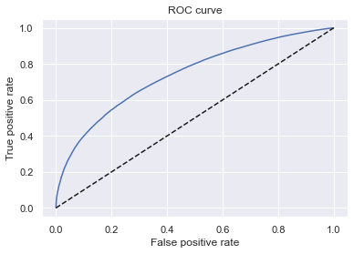

```python
# We plot the false positive rate along the x-axis and the true positive rate along the y-axis,
# thus plotting the ROC curve.
plt.plot(fpr, tpr)

# We plot a seconary diagonal line, with dashed line style and black color.
plt.plot(fpr, fpr, linestyle = '--', color = 'k')

# We name the x-axis "False positive rate".
plt.xlabel('False positive rate')

# We name the x-axis "True positive rate".
plt.ylabel('True positive rate')

# We name the graph "ROC curve".
plt.title('ROC curve')
```

```python
# Calculating the Area Under the Receiver Operating Characteristic Curve (AUROC)
# from a set of actual values and their predicted probabilities

AUROC = roc_auc_score(df_actual_predicted_probs['loan_data_targets_test'], df_actual_predicted_probs['y_hat_test_proba'])
AUROC
```

```
0.7393973640527626
```

The commond interpretation for area under the curve results is that: `The moodel is bad: 50 -60%` `The model is Poor: 60 - 70%` `The model is Fair: 70 - 80%` `The model is Good: 80 - 90%` `The model is Excellent: 90 - 100%`

We can conclude our model is fair.

**Gini and Kolmogorov-Smirnov**

These two are widely accepted in the credit risk modeling community for evaluation of model performance

```python
# Sorts a dataframe by the values of a specific column.
df_actual_predicted_probs = df_actual_predicted_probs.sort_values('y_hat_test_proba')
```

```python
# We reset the index of a dataframe and overwrite it.
df_actual_predicted_probs = df_actual_predicted_probs.reset_index()
```

```python
# We calculate the cumulative number of all observations.
# We use the new index for that. Since indexing in ython starts from 0, we add 1 to each index.
df_actual_predicted_probs['Cumulative N Population'] = df_actual_predicted_probs.index + 1

# We calculate cumulative number of 'good' borrowers, which is the cumulative sum of the column with actual observations.
df_actual_predicted_probs['Cumulative N Good'] = df_actual_predicted_probs['loan_data_targets_test'].cumsum()


# We calculate cumulative number of 'bad' borrwers, which is
# the difference between the cumulative number of all observations and cumulative number of 'good' for each row.
df_actual_predicted_probs['Cumulative N Bad'] = df_actual_predicted_probs['Cumulative N Population'] - df_actual_predicted_probs['loan_data_targets_test'].cumsum()
```

```python
# We calculate the cumulative percentage of all observations.
df_actual_predicted_probs['Cumulative Perc Population'] = df_actual_predicted_probs['Cumulative N Population'] / (df_actual_predicted_probs.shape[0])

# We calculate cumulative percentage of 'good'.
df_actual_predicted_probs['Cumulative Perc Good'] = df_actual_predicted_probs['Cumulative N Good'] / df_actual_predicted_probs['loan_data_targets_test'].sum()

# We calculate the cumulative percentage of 'bad'.
df_actual_predicted_probs['Cumulative Perc Bad'] = df_actual_predicted_probs['Cumulative N Bad'] / (df_actual_predicted_probs.shape[0] - df_actual_predicted_probs['loan_data_targets_test'].sum())
```

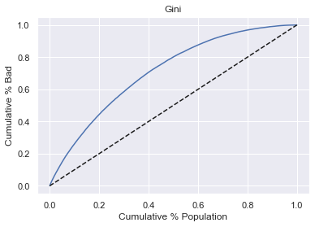

```python
# Plot Gini
# We plot the cumulative percentage of all along the x-axis and the cumulative percentage 'good' along the y-axis,
# thus plotting the Gini curve.
plt.plot(df_actual_predicted_probs['Cumulative Perc Population'], df_actual_predicted_probs['Cumulative Perc Bad'])


# We plot a seconary diagonal line, with dashed line style and black color.
plt.plot(df_actual_predicted_probs['Cumulative Perc Population'], df_actual_predicted_probs['Cumulative Perc Population'], linestyle = '--', color = 'k')


# We name the x-axis "Cumulative % Population".
plt.xlabel('Cumulative % Population')


# We name the y-axis "Cumulative % Bad".
plt.ylabel('Cumulative % Bad')


# We name the graph "Gini".
plt.title('Gini')
```

```python
# Here we calculate Gini from area under the curve
Gini = AUROC * 2 - 1
Gini
```

```
0.47879472810552515
```

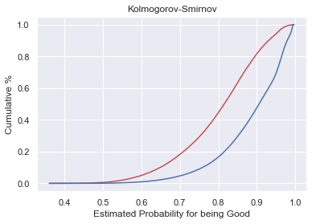

```python
# Plotting Kolmogorov-Smirnov (KS)
# We plot the predicted (estimated) probabilities along the x-axis and the cumulative percentage 'bad' along the y-axis,
# colored in red.
plt.plot(df_actual_predicted_probs['y_hat_test_proba'], df_actual_predicted_probs['Cumulative Perc Bad'], color = 'r')


# We plot the predicted (estimated) probabilities along the x-axis and the cumulative percentage 'good' along the y-axis,
# colored in blue.
plt.plot(df_actual_predicted_probs['y_hat_test_proba'], df_actual_predicted_probs['Cumulative Perc Good'], color = 'b')


# We name the x-axis "Estimated Probability for being Good".
plt.xlabel('Estimated Probability for being Good')


# We name the y-axis "Cumulative %".
plt.ylabel('Cumulative %')

# We name the graph "Kolmogorov-Smirnov".
plt.title('Kolmogorov-Smirnov')
```

We focus on the maximum distance between the red and the blue curve

```python
# We calculate KS from the data. It is the maximum of the difference between the cumulative percentage of 'bad'
# and the cumulative percentage of 'good'.
KS = max(df_actual_predicted_probs['Cumulative Perc Bad'] - df_actual_predicted_probs['Cumulative Perc Good'])
KS
```

```
0.35126542939112315
```

From the results of Gini and KS, the two cumulative distribution functions are sufficiently far away from each other and our model has satisfactory predictive power.

# APPLYING OUR PD MODEL FOR DECISION MAKING

**Calculating PD of individual accounts**

```python
# Sets the pandas dataframe options to display all columns/ rows.
pd.options.display.max_columns = None
```

```python
#inputs_test_with_ref_cat.head()
```

```python
#summary_table
```

```python
y_hat_test_proba
```

```
array([0.88852707, 0.85218165, 0.9581438 , ..., 0.98087661, 0.85860631,
       0.74650109])
```

**Creating a Scorecard**

Applying the scorecard is just like applying the PD model itself. The scorecard produces an individual credit worthiness assessment that directly corresponds to a specific probability of default, and because these credit worthiness are named after scorecard, they are called credit scores.

```python
#summary_table
```

```python
ref_categories
```

```
['grade:G',
 'home_ownership:RENT_OTHER_NONE_ANY',
 'addr_state:ND_NE_IA_NV_FL_HI_AL',
 'verification_status:Verified',
 'purpose:educ__sm_b__wedd__ren_en__mov__house',
 'initial_list_status:f',
 'term:60',
 'emp_length:0',
 'mths_since_issue_d:>84',
 'int_rate:>20.281',
 'mths_since_earliest_cr_line:<140',
 'delinq_2yrs:>=4',
 'inq_last_6mths:>6',
 'total_acc:<=27',
 'acc_now_delinq:0',
 'total_rev_hi_lim:<=5K',
 'annual_inc:<20K',
 'dti:>35',
 'mths_since_last_delinq:0-3',
 'mths_since_last_record:0-2']
```

```python
# We create a new dataframe with one column. Its values are the values from the 'reference_categories' list.
# We name it 'Feature name'.
df_ref_categories = pd.DataFrame(ref_categories, columns = ['Feature name'])

# We create a second column, called 'Coefficients', which contains only 0 values.
df_ref_categories['Coefficients'] = 0

# We create a third column, called 'p_values', with contains only NaN values.
df_ref_categories['p_values'] = np.nan

df_ref_categories
```

|  | Feature name | Coefficients | p_values |
| --- | --- | --- | --- |
| 0 | grade:G | 0 | NaN |
| 1 | home_ownership:RENT_OTHER_NONE_ANY | 0 | NaN |
| 2 | addr_state:ND_NE_IA_NV_FL_HI_AL | 0 | NaN |
| 3 | verification_status:Verified | 0 | NaN |
| 4 | purpose:educ__sm_b__wedd__ren_en__mov__house | 0 | NaN |
| 5 | initial_list_status:f | 0 | NaN |
| 6 | term:60 | 0 | NaN |
| 7 | emp_length:0 | 0 | NaN |
| 8 | mths_since_issue_d:>84 | 0 | NaN |
| 9 | int_rate:>20.281 | 0 | NaN |
| 10 | mths_since_earliest_cr_line:<140 | 0 | NaN |
| 11 | delinq_2yrs:>=4 | 0 | NaN |
| 12 | inq_last_6mths:>6 | 0 | NaN |
| 13 | total_acc:<=27 | 0 | NaN |
| 14 | acc_now_delinq:0 | 0 | NaN |
| 15 | total_rev_hi_lim:<=5K | 0 | NaN |
| 16 | annual_inc:<20K | 0 | NaN |
| 17 | dti:>35 | 0 | NaN |
| 18 | mths_since_last_delinq:0-3 | 0 | NaN |
| 19 | mths_since_last_record:0-2 | 0 | NaN |

```python
# Concatenates two dataframes.
df_scorecard = pd.concat([summary_table, df_ref_categories])


# We reset the index of a dataframe.
df_scorecard = df_scorecard.reset_index()

#df_scorecard
```

```python
# We create a new column, called 'Original feature name', which contains the value of the 'Feature name' column,
# up to the column symbol.
df_scorecard['Original feature name'] = df_scorecard['Feature name'].str.split(':').str[0]
```

```python
#df_scorecard
```

```python
min_score = 300
max_score = 850
```

```python
# Groups the data by the values of the 'Original feature name' column.
# Aggregates the data in the 'Coefficients' column, calculating their minimum.
df_scorecard.groupby('Original feature name')['Coefficients'].min()
```

```
Original feature name
Intercept                      0.422957
acc_now_delinq                 0.000000
addr_state                    -0.002318
annual_inc                    -0.098689
delinq_2yrs                    0.000000
dti                           -0.074968
emp_length                     0.000000
grade                          0.000000
home_ownership                 0.000000
initial_list_status            0.000000
inq_last_6mths                 0.000000
int_rate                      -0.217905
mths_since_earliest_cr_line   -0.093358
mths_since_issue_d            -1.634308
mths_since_last_delinq         0.000000
mths_since_last_record        -0.002880
purpose                        0.000000
term                           0.000000
total_acc                     -0.116590
total_rev_hi_lim               0.000000
verification_status            0.000000
Name: Coefficients, dtype: float64
```

```python
# Up to the 'min()' method everything is the same as in te line above.
# Then, we aggregate further and sum all the minimum values.
min_sum_coef = df_scorecard.groupby('Original feature name')['Coefficients'].min().sum()
min_sum_coef
```

```
-1.8180596921848782
```

```python
# Groups the data by the values of the 'Original feature name' column.
# Aggregates the data in the 'Coefficients' column, calculating their maximum.
df_scorecard.groupby('Original feature name')['Coefficients'].max()
```

```
Original feature name
Intercept                      0.422957
acc_now_delinq                 0.117037
addr_state                     0.423568
annual_inc                     0.174567
delinq_2yrs                    0.035874
dti                            0.211483
emp_length                     0.154783
grade                          2.155770
home_ownership                 0.243026
initial_list_status            0.100388
inq_last_6mths                 0.759995
int_rate                       0.021687
mths_since_earliest_cr_line    0.000000
mths_since_issue_d             0.000000
mths_since_last_delinq         0.149150
mths_since_last_record         0.091829
purpose                        0.180384
term                           0.190915
total_acc                      0.000000
total_rev_hi_lim               0.315802
verification_status            0.249651
Name: Coefficients, dtype: float64
```

```python
# Up to the 'min()' method everything is the same as in te line above.
# Then, we aggregate further and sum all the maximum values.
max_sum_coef = df_scorecard.groupby('Original feature name')['Coefficients'].max().sum()
max_sum_coef
```

```
5.9988648099694135
```

```python
# We multiply the value of the 'Coefficients' column by the ration of the differences between
# maximum score and minimum score and maximum sum of coefficients and minimum sum of cefficients.
df_scorecard['Score - Calculation'] = df_scorecard['Coefficients'] * (max_score - min_score) / (max_sum_coef - min_sum_coef)
#df_scorecard
```

```python
# We divide the difference of the value of the 'Coefficients' column and the minimum sum of coefficients by
# the difference of the maximum sum of coefficients and the minimum sum of coefficients.
# Then, we multiply that by the difference between the maximum score and the minimum score.
# Then, we add minimum score.

df_scorecard['Score - Calculation'][0] = ((df_scorecard['Coefficients'][0] - min_sum_coef) / (max_sum_coef - min_sum_coef)) * (max_score - min_score) + min_score

#df_scorecard
```

```python
# We round the values of the 'Score - Calculation' column.
df_scorecard['Score - Preliminary'] = df_scorecard['Score - Calculation'].round()

#df_scorecard
```